# Left Behind

Sep 2025: Analysis

# Purpose

This is a pilot study that is intended to further explore the feeling of being left behind. Specifically, we wanted to see what people intuitively write when prompted to think of the ways in which they are being left behind. Potentially, the extent to which they feel left behind, interacted with the way in which they are left behind, inform important political outcomes.

# Procedure

## Demographics

Demographic information, political ideology, and political party identification.

## Left behind

### Continuous measure

They indicated the extent to which they feel left behind on a scale of 0-100.

### Open-ended measure

They wrote, in detail, what feeling left behind means to them and what are the factors that are contributing to that feeling.

### Dimensions of feeling behind

They rated their response on a number of follow-up measures: systemic-individual; relation to government; economic-cultural; historic-recent; trajectory.

## Outcomes

Random order: (1) support for anti-democratic practices; (2) ideal candidate for an election;  
Random order: (3) anti-establishment sentiment; (4) trust in institutions.  
Finally, participants indicated their voting behavior in 2024.

# Eligibility

There was on bot-check with an invisible attention check.

```r
eligible_n <- df_lebe %>%
  group_by(is_elg) %>%
  summarise(n = n()) %>%
  ungroup() %>%
  filter(is_elg == 1) %>%
  select(n) %>%
  unlist() %>%
  unname()

df_lebe %>%
  group_by(att_1) %>%
  summarise(N = n()) %>%
  ungroup() %>%
  mutate(Perc = round(100*(N/sum(N)),2)) %>%
  ungroup() %>%
  kbl() %>%
  kable_styling(bootstrap_options = "hover",
                full_width = F,
                position = "left")
```

| att_1 | N | Perc |
| --- | --- | --- |
| 1 | 198 | 100 |

That gives us a total of 198 eligible participants.  
Participants were recruited through Prolific and the following quota was set for political representativeness: (30% dems; 30% reps; 40% independents)

# Demographics

## Race

```r
df_lebe_elg %>%
  group_by(race) %>%
  summarise(N = n()) %>%
  ungroup() %>%
  mutate(Perc = round(100*(N/sum(N)),2)) %>%
  ungroup() %>%
  arrange(desc(N)) %>%
  kbl() %>%
  kable_styling(bootstrap_options = "hover",
                full_width = F,
                position = "left")
```

| race | N | Perc |
| --- | --- | --- |
| White | 142 | 71.72 |
| Black or African American | 19 | 9.60 |
| Asian | 13 | 6.57 |
| Hispanic, Latino, or Spanish origin | 12 | 6.06 |
| multiracial | 9 | 4.55 |
| NA | 2 | 1.01 |
| Middle Eastern or North African | 1 | 0.51 |

## Gender

```r
df_lebe_elg %>%
  mutate(gender = ifelse(is.na(gender) | gender == "","other",gender)) %>%
  group_by(gender) %>%
  summarise(N = n()) %>%
  ungroup() %>%
  mutate(Perc = round(100*(N/sum(N)),2)) %>%
  ungroup() %>%
  arrange(desc(N)) %>%
  kbl() %>%
  kable_styling(bootstrap_options = "hover",
                full_width = F,
                position = "left")
```

| gender | N | Perc |
| --- | --- | --- |
| man | 97 | 48.99 |
| woman | 97 | 48.99 |
| other | 4 | 2.02 |

## Age

```r
df_lebe_elg %>%
  summarise(age_mean = round(mean(age,na.rm = T),2),
            age_sd = round(sd(age,na.rm = T),2)) %>%
  kbl() %>%
  kable_styling(bootstrap_options = "hover",
                full_width = F,
                position = "left")
```

| age_mean | age_sd |
| --- | --- |
| 46.42 | 12.89 |

## Education

```r
df_lebe_elg %>%
  group_by(edu) %>%
  summarise(N = n()) %>%
  ungroup() %>%
  mutate(Perc = round(100*(N/sum(N)),2)) %>%
  ungroup() %>%
  kbl() %>%
  kable_styling(bootstrap_options = "hover",
                full_width = F,
                position = "left")
```

| edu | N | Perc |
| --- | --- | --- |
| noHS | 2 | 1.01 |
| GED | 60 | 30.30 |
| 2yearColl | 25 | 12.63 |
| 4yearColl | 71 | 35.86 |
| MA | 24 | 12.12 |
| PHD | 15 | 7.58 |
| NA | 1 | 0.51 |

## Income

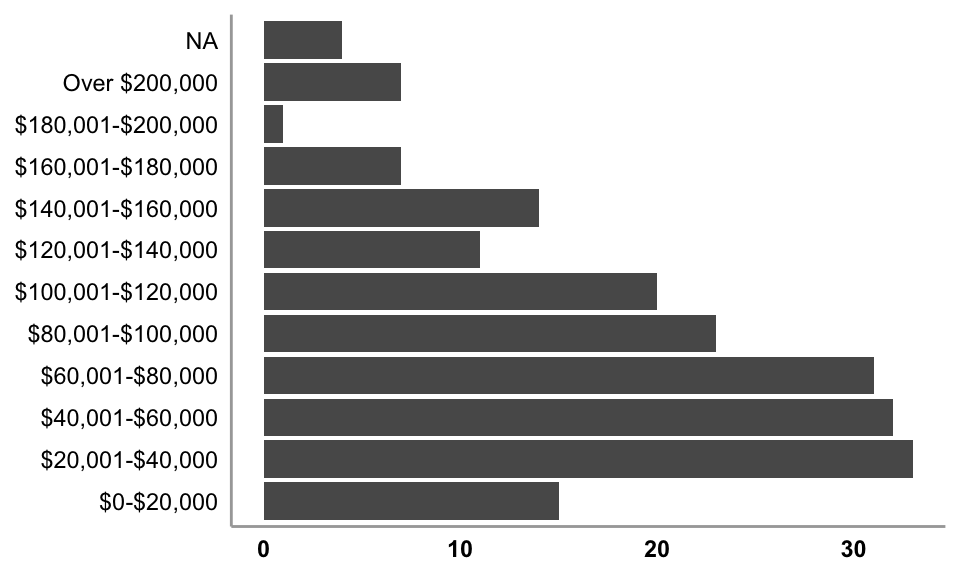

```r
df_lebe_elg %>%
  ggplot(aes(x = income)) +
  geom_bar() +
  theme(panel.grid.major = element_blank(),
        panel.grid.minor = element_blank(),
        panel.background = element_blank(),
        axis.ticks = element_blank(),
        axis.line = element_line(color = "grey66"),
        axis.text.y = element_text(color = "black"),
        axis.text.x = element_text(color = "black",
                                   face = "bold"),
        axis.title.x = element_blank(),
        axis.title.y = element_blank()) +
  coord_flip()
```

# Politics

## Ideology

Participants were asked about the extent to which they subscribe to the following ideologies on a scale of 1-7 (select NA if unfamiliar): Conservatism, Liberalism, Democratic Socialism, Libertarianism, Progressivism.

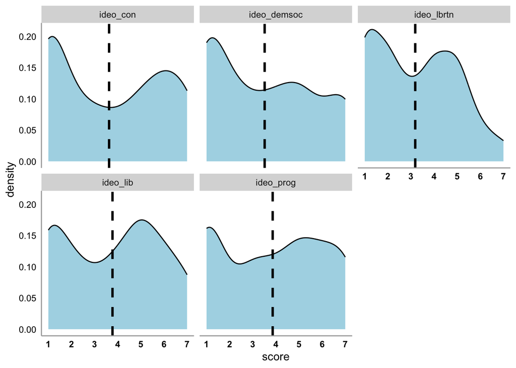

```r
means <- df_lebe_elg %>%
  dplyr::select(PID,ideo_con:ideo_prog) %>%
  pivot_longer(-PID,
               names_to = "ideo",
               values_to = "score") %>%
  filter(!is.na(score)) %>%
  group_by(ideo) %>%
  summarise(score = mean(score)) %>%
  ungroup()

df_lebe_elg %>%
  dplyr::select(PID,ideo_con:ideo_prog) %>%
  pivot_longer(-PID,
               names_to = "ideo",
               values_to = "score") %>%
  filter(!is.na(score)) %>%
  ggplot() +
  geom_density(aes(x = score), fill = "lightblue") +
  scale_x_continuous(limits = c(1,7),
                     breaks = seq(1,7,1)) +
  geom_vline(data = means,mapping = aes(xintercept = score),
             color = "black",
             linetype = "dashed",
             size = 1.1) +
  theme(panel.grid.major = element_blank(),
        panel.grid.minor = element_blank(),
        panel.background = element_blank(),
        axis.ticks = element_blank(),
        axis.line = element_line(color = "grey66"),
        axis.text.y = element_text(color = "black"),
        axis.text.x = element_text(color = "black",
                                   face = "bold")) +
  facet_wrap(~ideo,nrow = 2)
```

## Party ID

### Initial selection

```r
df_lebe_elg %>%
  group_by(party_gen) %>%
  summarise(N = n()) %>%
  ungroup() %>%
  mutate(Perc = round(100*(N/sum(N)),2)) %>%
  ungroup() %>%
  arrange(desc(N)) %>%
  kbl() %>%
  kable_styling(bootstrap_options = "hover",
                full_width = F,
                position = "left")
```

| party_gen | N | Perc |
| --- | --- | --- |
| Independent | 69 | 34.85 |
| Democrat | 63 | 31.82 |
| Republican | 61 | 30.81 |
| No preference | 3 | 1.52 |
| Other party | 2 | 1.01 |

### With followups

```r
df_lebe_elg %>%
  group_by(party_followup) %>%
  summarise(N = n()) %>%
  ungroup() %>%
  mutate(Perc = round(100*(N/sum(N)),2)) %>%
  ungroup() %>%
  kbl() %>%
  kable_styling(bootstrap_options = "hover",
                full_width = F,
                position = "left")
```

| party_followup | N | Perc |
| --- | --- | --- |
| Democrat \| Not very strong | 27 | 13.64 |
| Democrat \| Strong | 36 | 18.18 |
| Independent \| Closer to Democratic | 32 | 16.16 |
| Independent \| Closer to Republican | 15 | 7.58 |
| Independent \| Neither | 27 | 13.64 |
| Republican \| Not very strong | 33 | 16.67 |
| Republican \| Strong | 28 | 14.14 |

### Voting behavior: 2024

Who did you vote for in the 2024 Presidential Election?

```r
df_lebe_elg %>%
  group_by(vote_2024) %>%
  summarise(N = n()) %>%
  ungroup() %>%
  mutate(Perc = round(100*(N/sum(N)),2)) %>%
  ungroup() %>%
  arrange(desc(N)) %>%
  kbl() %>%
  kable_styling(bootstrap_options = "hover",
                full_width = F,
                position = "left")
```

| vote_2024 | N | Perc |
| --- | --- | --- |
| Kamala Harris (Democratic Party) | 97 | 48.99 |
| Donald Trump (Republican Party) | 78 | 39.39 |
| I did not vote | 19 | 9.60 |
| Jill Stein (Green Party) | 3 | 1.52 |
| i voted for myself honestl | 1 | 0.51 |

# Measures

## Left behind

### Continuous

People in America come from all walks of life. Some feel left behind. We are interested in whether you feel left behind and what that means for you.  
**To what extent do you feel left behind?** (0 = *Not at All Left Behind* to 100 = *Extremely Left Behind*)

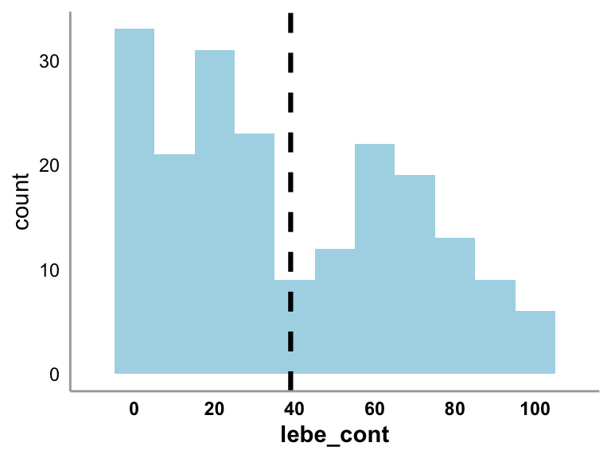

```r
df_lebe_elg %>%
  ggplot(aes(x = lebe_cont)) +
  geom_histogram(fill = "lightblue",
                 binwidth = 10) +
  scale_x_continuous(breaks = seq(0,100,20),
                     limits = c(-10,110)) +
  ylab("count") +
  geom_vline(xintercept = mean(df_lebe_elg$lebe_cont,na.rm = T),
             color = "black",
             linetype = "dashed",
             size = 1.1) +
  theme(panel.grid.major = element_blank(),
        panel.grid.minor = element_blank(),
        panel.background = element_blank(),
        axis.ticks = element_blank(),
        axis.line = element_line(color = "grey66"),
        axis.text.y = element_text(color = "black"),
        axis.text.x = element_text(color = "black",
                                   face = "bold"),
        axis.title.x = element_text(color = "black",
                                   face = "bold"))
```

Interesting. Most people are under the mid-point. Ok.

### Open-ended description

[For those under 50 in the continuous measure:  
Although not everyone might feel overall left behind to the same extent, everyone likely does feel left behind in at least a few ways. So, regardless of your answer to the previous question…]  
**What does the phrase ‘feeling left behind’ mean to you in your own life? In what ways[,if any,] do you feel left behind, and why?**  
Please describe why you might feel left behind in as much detail as possible. There is no right or wrong answer here; just your honest thoughts about the factors that might make you feel left behind.  
*paste disabled*  
character range: 100-5000  
Note: Adding their self-reported left-behind scores to the table below as well.

| lebe_cont | describe |
| --- | --- |
| 0 | Feeling left behind might mean everyone else has a life and has accomplished something and you might now feel that way. I don’t feel left behind. My life feels full, I feel accomplished, I’m happy wit… |
| 35 | I feel left behind economically and job wise. No matter what I do nothing is really working out for me. I also feel left behind in life. I have no family and do not have a house of my own. |
| 100 | I have next to no income, I am disabled, and I don’t qualify for government benefits since I don’t have enough money for more up to date doctors notes. It’s really disheartening and I see the people I… |
| 26 | Not being given equal opportunity in life in regards to school, jobs, and extracurricular activities. I would not say i was necessarily left behind but my parents did have to do some work to get me in… |
| 60 | I feel left behind in terms of finances and a career. I’ve been unemployed for 9 months now and it sucks that I am unable to find a job. I’ve been making income through gig work, but it feels like I’m… |
| 20 | I don’t really feel left behind, as things have turned out well in my life. I make decent money, actually enjoy my job and have an amazing life partner |
| 30 | For me, being left behind relates to times when I have struggled in my life. Financially, when I have struggled, I am someone who falls between the cracks/was just beyond qualification for help. I als… |
| 80 | I feel left behind due to my lack of experiences. I have little to no social skills and my finances aren’t the greatest but improving due to effort. I feel left behind due my own actions not the fault… |
| 71 | I think it mainly means financially left behind. It seems like it was easier to afford a home in the past, for example. My parents were able to buy a nice house with a huge garage and backyard on two … |
| 100 | I am behind because I will never be able to afford anything. I will never be able to afford a house, and I can just hope that my parents keep theirs so that I can inherit it. I am also not going to ha… |
| 31 | I guess I could feel left behind because of technology or being part of the culture. I don’t feel left behind because I am tech savvy and don’t need to feel connected to the world in a way that i need… |
| 72 | I feel left behind due to not progressing in most areas compared to others in my age and life stage. I’m behind on my career, family, and just everything it seems |
| 78 | I think it means how you evaluate your life and your contentment with it relative to expectations. I feel I’m currently struggling with a number of issues both financially and with my relationships as… |
| 35 | I feel that I am left behind. I was trained in Law Enforcement and did that for 7 years. Due to my partners murder, I developed crippling anxiety and left the profession. I then became a bookkeeper. h… |
| 9 | I feel left behind as a single parent because I struggle a lot to keep myself afloat. I have a lot to juggle in my daily life with very little support. |
| 30 | I feel left behind by employment and other issues like women getting more attention than men these days. Especially when it comes to being employed. There are better chances for women to be employed t… |
| 73 | Sometimes I feel left behind when I see people my age already doing things I want to do, like having better careers and nicer homes, while I’m still working towards those goals. It makes me feel like … |
| 19 | Right now I feel a little left behind because of the job market. It is very hard getting a job that pays well right now. No jobs in this small town. |
| 29 | The only way I feel left behind is because I am underestimated due to my age. I am active, strong, healthy, computer literate, smartphone literate, and stay on top of the news. I am routinely outright… |
| 0 | I don’t feel left behind in any sense of the phrase but given the high cost of living I can understand why many feel like they can barely survive day to day with no hope of improving their situation a… |
| 55 | I feel left behind as I don’t think I value the same things that my peers value. I value the Earth and nature, and I spend a lot of my time immersed in the outdoors. I feel like most people are more f… |
| 61 | It means not represented by the status quo and not having your voice represented by your elected officials. |
| 40 | I think of left behind as whether I have more opportunities and financial security as my parents. It is a generational measure. |
| 60 | I think financially. Trying to make money today seems to be pretty hard to do. I enjoy making content online, but it is hard to stand out! |
| 6 | Age is discriminated agains in this country. It is especially difficult to find employment regardless of education and years of experience. With age comes knowledge and wisdom which is not thought of … |
| 75 | I felt left behind because I am being taxed so much that I can not accomplish my life’s goals. My elected representatives seem unaware and unconcerned about the level of taxation that is holding peopl… |
| 75 | I feel left behind because, through no (or little) fault of my own, I have been out of the workforce for almost 9 years. Took care of a family member after a stroke, covid, mental health challenges af… |
| 23 | like others have made it in life and you havent gotten anywhere,you just stagnant ,thigs are not going on well with you, |
| 10 | While growing up as one of four kids I often felt left behind, ignored or lost. Pretty sure my parents liked the other siblings better than me and I think at age 66 that holds true . I feel bad but th… |
| 80 | I feel left behind because I pay a good amount of taxes as a single person living in an expensive place like California, and I don’t get anything in return for it. |

[output cut: 168 more lines]

### Dimensions of feeling left behind

#### Systemic-Individual

Would you say the factors that make you feel left behind are more **systemic** (larger forces outside your control, like government, society, culture, or the economy) or more **individual** (your own circumstances and choices)? (1 = *Entirely Systemic* to 7 = *Entirely Individual*)  
*Note: I reverse-scored it here so it’s more intuitive for us.

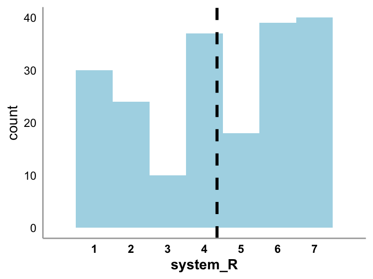

```r
df_lebe_elg %>%
  ggplot(aes(x = system_R)) +
  geom_histogram(fill = "lightblue",
                 binwidth = 1) +
  scale_x_continuous(breaks = seq(1,7,1),
                     limits = c(0,8)) +
  ylab("count") +
  geom_vline(xintercept = mean(df_lebe_elg$system_R,na.rm = T),
             color = "black",
             linetype = "dashed",
             size = 1.1) +
  theme(panel.grid.major = element_blank(),
        panel.grid.minor = element_blank(),
        panel.background = element_blank(),
        axis.ticks = element_blank(),
        axis.line = element_line(color = "grey66"),
        axis.text.y = element_text(color = "black"),
        axis.text.x = element_text(color = "black",
                                   face = "bold"),
        axis.title.x = element_text(color = "black",
                                   face = "bold"))
```

#### Relation to government

To what extent are the factors contributing to you feeling left behind related to the government? (1 = *Not at all related to the government* to 5 = *Extremely related to the government*)

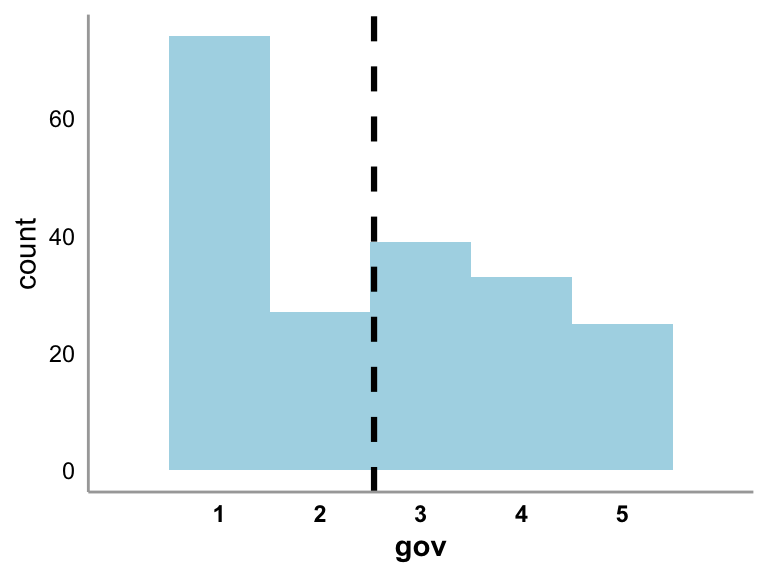

```r
df_lebe_elg %>%
  ggplot(aes(x = gov)) +
  geom_histogram(fill = "lightblue",
                 binwidth = 1) +
  scale_x_continuous(breaks = seq(1,5,1),
                     limits = c(0,6)) +
  ylab("count") +
  geom_vline(xintercept = mean(df_lebe_elg$gov,na.rm = T),
             color = "black",
             linetype = "dashed",
             size = 1.1) +
  theme(panel.grid.major = element_blank(),
        panel.grid.minor = element_blank(),
        panel.background = element_blank(),
        axis.ticks = element_blank(),
        axis.line = element_line(color = "grey66"),
        axis.text.y = element_text(color = "black"),
        axis.text.x = element_text(color = "black",
                                   face = "bold"),
        axis.title.x = element_text(color = "black",
                                   face = "bold"))
```

#### Economic-Cultural

Would you say the factors that make you feel left behind are more **economic** (like income, affordability, financial security) or **cultural** (like dignity, feeling respected, feeling valued)? (1 = *Entirely Economic* to 7 = *Entirely Cultural*)

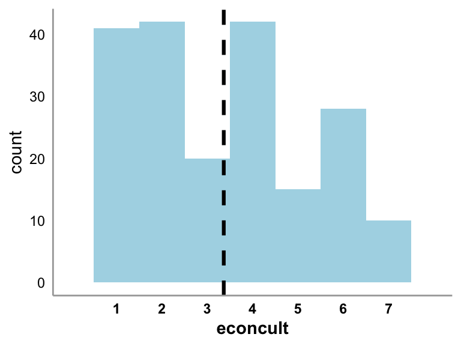

```r
df_lebe_elg %>%
  ggplot(aes(x = econcult)) +
  geom_histogram(fill = "lightblue",
                 binwidth = 1) +
  scale_x_continuous(breaks = seq(1,7,1),
                     limits = c(0,8)) +
  ylab("count") +
  geom_vline(xintercept = mean(df_lebe_elg$econcult,na.rm = T),
             color = "black",
             linetype = "dashed",
             size = 1.1) +
  theme(panel.grid.major = element_blank(),
        panel.grid.minor = element_blank(),
        panel.background = element_blank(),
        axis.ticks = element_blank(),
        axis.line = element_line(color = "grey66"),
        axis.text.y = element_text(color = "black"),
        axis.text.x = element_text(color = "black",
                                   face = "bold"),
        axis.title.x = element_text(color = "black",
                                   face = "bold"))
```

#### History

Would you say that the factors contributing to you feeling left behind are more **historic** (i.e.,they have been present for many years) or more **recent** (i.e., they are relatively new)? (1 = *Entirely Historic* to 7 = *Entirely Recent*)

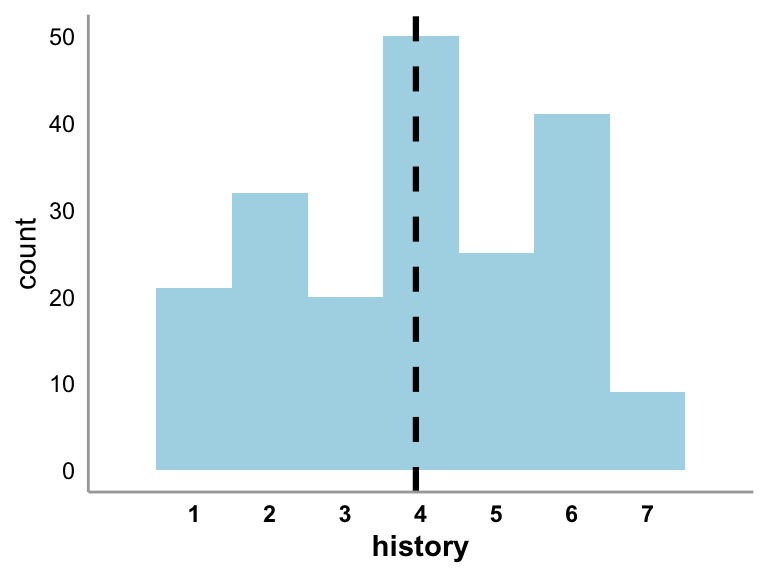

```r
df_lebe_elg %>%
  ggplot(aes(x = history)) +
  geom_histogram(fill = "lightblue",
                 binwidth = 1) +
  scale_x_continuous(breaks = seq(1,7,1),
                     limits = c(0,8)) +
  ylab("count") +
  geom_vline(xintercept = mean(df_lebe_elg$history,na.rm = T),
             color = "black",
             linetype = "dashed",
             size = 1.1) +
  theme(panel.grid.major = element_blank(),
        panel.grid.minor = element_blank(),
        panel.background = element_blank(),
        axis.ticks = element_blank(),
        axis.line = element_line(color = "grey66"),
        axis.text.y = element_text(color = "black"),
        axis.text.x = element_text(color = "black",
                                   face = "bold"),
        axis.title.x = element_text(color = "black",
                                   face = "bold"))
```

#### Trajectory

Would you say that the trajectory of the factors contributing to you feeling left behind is **negative** (i.e., things are getting worse) or **positive** (i.e., things are getting better)? (1 = *Extremely Negative* to 7 = *Extremely Positive*)

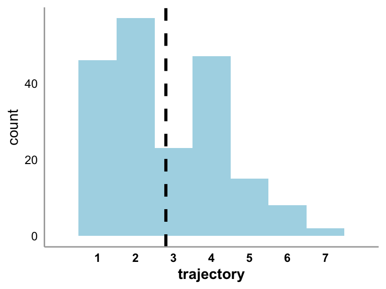

```r
df_lebe_elg %>%
  ggplot(aes(x = trajectory)) +
  geom_histogram(fill = "lightblue",
                 binwidth = 1) +
  scale_x_continuous(breaks = seq(1,7,1),
                     limits = c(0,8)) +
  ylab("count") +
  geom_vline(xintercept = mean(df_lebe_elg$trajectory,na.rm = T),
             color = "black",
             linetype = "dashed",
             size = 1.1) +
  theme(panel.grid.major = element_blank(),
        panel.grid.minor = element_blank(),
        panel.background = element_blank(),
        axis.ticks = element_blank(),
        axis.line = element_line(color = "grey66"),
        axis.text.y = element_text(color = "black"),
        axis.text.x = element_text(color = "black",
                                   face = "bold"),
        axis.title.x = element_text(color = "black",
                                   face = "bold"))
```

### Text analysis

I looped through their open-ended responses with gpt-4o to get the following: (1) left behind score; (2) labeled reasons; (3) systemic to individual; (4) government-related; (5) economic to cultural; (6) history; (7) trajectory.

#### Left behind score

To what extent is this person feeling left behind?

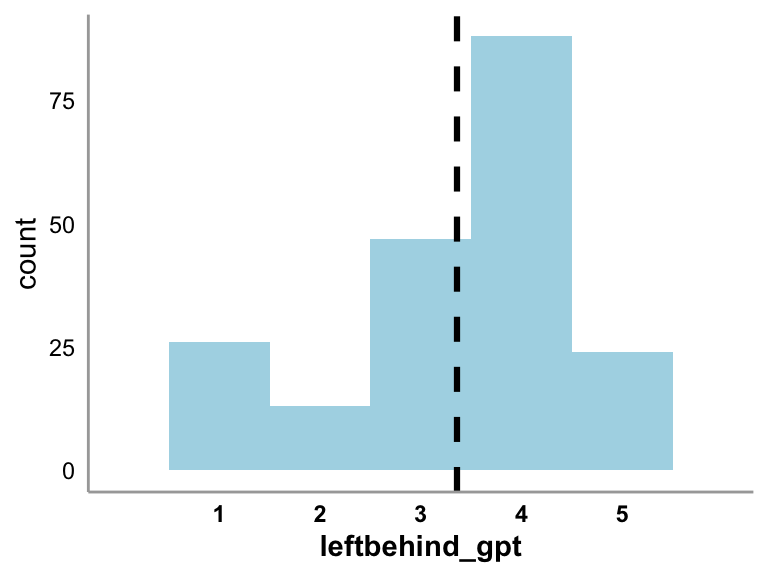

```r
df_lebe_elg %>%
  ggplot(aes(x = leftbehind_gpt)) +
  geom_histogram(fill = "lightblue",
                 binwidth = 1) +
  scale_x_continuous(breaks = seq(1,5,1),
                     limits = c(0,6)) +
  ylab("count") +
  geom_vline(xintercept = mean(df_lebe_elg$leftbehind_gpt,na.rm = T),
             color = "black",
             linetype = "dashed",
             size = 1.1) +
  theme(panel.grid.major = element_blank(),
        panel.grid.minor = element_blank(),
        panel.background = element_blank(),
        axis.ticks = element_blank(),
        axis.line = element_line(color = "grey66"),
        axis.text.y = element_text(color = "black"),
        axis.text.x = element_text(color = "black",
                                   face = "bold"),
        axis.title.x = element_text(color = "black",
                                   face = "bold"))
```

#### Reasons

What are the factors that are making this person feel left behind?  
Note: I’ll skip the analysis on this for now, but I think this can be useful if we want to do embeddings later on.

```r
df_lebe_elg %>%
  select(reasons) %>%
  kbl() %>%
  kable_styling(bootstrap_options = "hover",
                position = "left") %>%
  scroll_box(width = "100%", height = "400px")
```

| reasons |
| --- |
| none |
| economic struggles, career stagnation, lack of family, housing insecurity |
| low income, disability, lack of benefits, medical documentation, financial instability, peer comparison |
| educational inequality, zoning restrictions, economic disparity, opportunity gap |
| unemployment, gig work, career stagnation, financial stress, self-fulfillment, peer comparison |
| none |
| financial struggles, health insurance, qualification gaps |
| lack of experiences, social skills, financial struggles, personal actions |
| housing costs, financial disparity, economic changes |
| housing costs, financial insecurity, lack of milestones, inheritance reliance, retirement concerns, economic disparity |
| technology, cultural shifts |
| career stagnation, family expectations, peer comparison, financial instability, educational gaps |
| financial struggles, relationship issues |
| career change, job loss, technology advancement, age concerns, anxiety, trauma, automation impact |
| single parent, lack of support, financial stress, time constraints |
| employment, gender bias, income disparity |
| career progress, housing costs, peer comparison, personal goals |
| job market, small town, low pay |
| ageism, underestimation, stereotypes, exclusion, disrespect |
| high cost of living, economic disparity, job insecurity, inflation, wage stagnation |
| different values, nature focus, peer pressure, tech gap, work priorities |
| lack of representation, political exclusion |
| financial security, opportunity gap, generational comparison |
| financial struggles, online competition |
| age discrimination, employment challenges, undervalued experience, knowledge overlooked |
| high taxes, political neglect, unfair spending |
| age discrimination, job market, economic conditions, mental health, caregiving responsibilities, covid impact, financial instability |
| career stagnation, financial struggles, lack of progress, missed opportunities, peer comparison |
| sibling favoritism, academic performance, lack of attention, family dynamics |
| high taxes, cost of living, single status, lack of benefits |

[output cut: 168 more lines]

#### System to individual

Would you say that the factors that make this person feel left behind are more systemic (larger forces outside their control, like government, society, culture, or the economy) or more individual (their own circumstances and choice)?

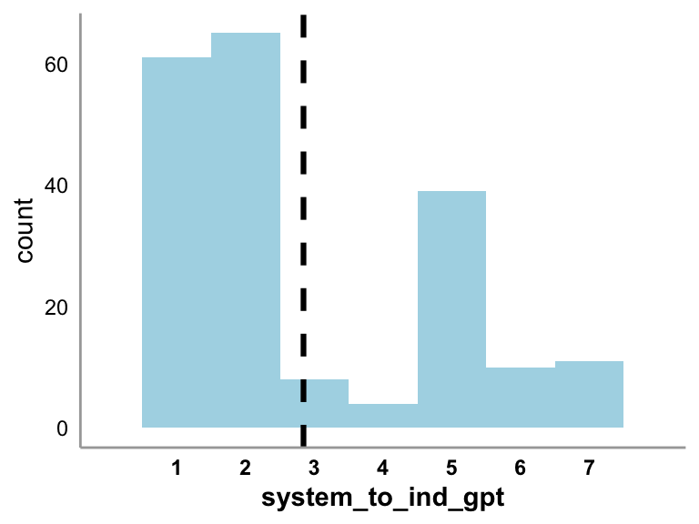

```r
df_lebe_elg %>%
  ggplot(aes(x = system_to_ind_gpt)) +
  geom_histogram(fill = "lightblue",
                 binwidth = 1) +
  scale_x_continuous(breaks = seq(1,7,1),
                     limits = c(0,8)) +
  ylab("count") +
  geom_vline(xintercept = mean(df_lebe_elg$system_to_ind_gpt,na.rm = T),
             color = "black",
             linetype = "dashed",
             size = 1.1) +
  theme(panel.grid.major = element_blank(),
        panel.grid.minor = element_blank(),
        panel.background = element_blank(),
        axis.ticks = element_blank(),
        axis.line = element_line(color = "grey66"),
        axis.text.y = element_text(color = "black"),
        axis.text.x = element_text(color = "black",
                                   face = "bold"),
        axis.title.x = element_text(color = "black",
                                   face = "bold"))
```

#### Government-related

To what extent are the factors related to the government?

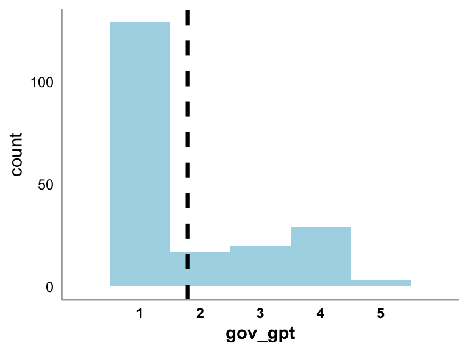

```r
df_lebe_elg %>%
  ggplot(aes(x = gov_gpt)) +
  geom_histogram(fill = "lightblue",
                 binwidth = 1) +
  scale_x_continuous(breaks = seq(1,5,1),
                     limits = c(0,6)) +
  ylab("count") +
  geom_vline(xintercept = mean(df_lebe_elg$gov_gpt,na.rm = T),
             color = "black",
             linetype = "dashed",
             size = 1.1) +
  theme(panel.grid.major = element_blank(),
        panel.grid.minor = element_blank(),
        panel.background = element_blank(),
        axis.ticks = element_blank(),
        axis.line = element_line(color = "grey66"),
        axis.text.y = element_text(color = "black"),
        axis.text.x = element_text(color = "black",
                                   face = "bold"),
        axis.title.x = element_text(color = "black",
                                   face = "bold"))
```

#### Economic to cultural

To what extent are the factors more economic (like income, affordability, financial security) or cultural (like dignity, feeling respected, feeling valued)?

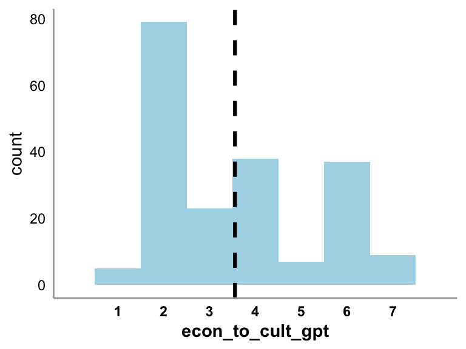

```r
df_lebe_elg %>%
  ggplot(aes(x = econ_to_cult_gpt)) +
  geom_histogram(fill = "lightblue",
                 binwidth = 1) +
  scale_x_continuous(breaks = seq(1,7,1),
                     limits = c(0,8)) +
  ylab("count") +
  geom_vline(xintercept = mean(df_lebe_elg$econ_to_cult_gpt,na.rm = T),
             color = "black",
             linetype = "dashed",
             size = 1.1) +
  theme(panel.grid.major = element_blank(),
        panel.grid.minor = element_blank(),
        panel.background = element_blank(),
        axis.ticks = element_blank(),
        axis.line = element_line(color = "grey66"),
        axis.text.y = element_text(color = "black"),
        axis.text.x = element_text(color = "black",
                                   face = "bold"),
        axis.title.x = element_text(color = "black",
                                   face = "bold"))
```

#### Historic

To what extent are the factors more historic (i.e., they have been present for many years) or more recent (i.e., they are relatively new)? (Historic to recent)

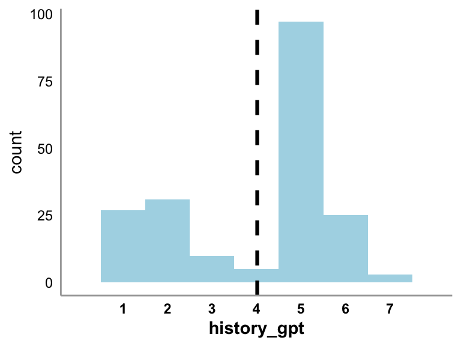

```r
df_lebe_elg %>%
  ggplot(aes(x = history_gpt)) +
  geom_histogram(fill = "lightblue",
                 binwidth = 1) +
  scale_x_continuous(breaks = seq(1,7,1),
                     limits = c(0,8)) +
  ylab("count") +
  geom_vline(xintercept = mean(df_lebe_elg$history_gpt,na.rm = T),
             color = "black",
             linetype = "dashed",
             size = 1.1) +
  theme(panel.grid.major = element_blank(),
        panel.grid.minor = element_blank(),
        panel.background = element_blank(),
        axis.ticks = element_blank(),
        axis.line = element_line(color = "grey66"),
        axis.text.y = element_text(color = "black"),
        axis.text.x = element_text(color = "black",
                                   face = "bold"),
        axis.title.x = element_text(color = "black",
                                   face = "bold"))
```

#### Trajectory

Is the trajectory of the factors negative (i.e., things are getting worse) or positive (i.e., things are getting better)?

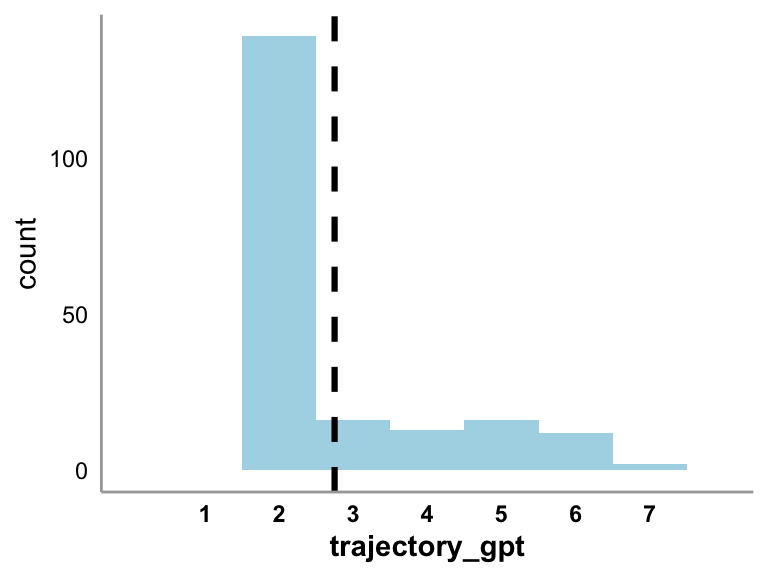

```r
df_lebe_elg %>%
  ggplot(aes(x = trajectory_gpt)) +
  geom_histogram(fill = "lightblue",
                 binwidth = 1) +
  scale_x_continuous(breaks = seq(1,7,1),
                     limits = c(0,8)) +
  ylab("count") +
  geom_vline(xintercept = mean(df_lebe_elg$trajectory_gpt,na.rm = T),
             color = "black",
             linetype = "dashed",
             size = 1.1) +
  theme(panel.grid.major = element_blank(),
        panel.grid.minor = element_blank(),
        panel.background = element_blank(),
        axis.ticks = element_blank(),
        axis.line = element_line(color = "grey66"),
        axis.text.y = element_text(color = "black"),
        axis.text.x = element_text(color = "black",
                                   face = "bold"),
        axis.title.x = element_text(color = "black",
                                   face = "bold"))
```

### Cosine similarity measures

From the reasons that I extracted with gpt-4o, I got openai word embeddings. I did this to assess how cohesive the reasons for falling behind are for every person. To that end, I arrived at two measure:

#### MPCS

This is just the mean of the pairwise cosine similarities of all possible within-participant embeddings. So, higher scores mean that the reasons are more alike in semantic space.

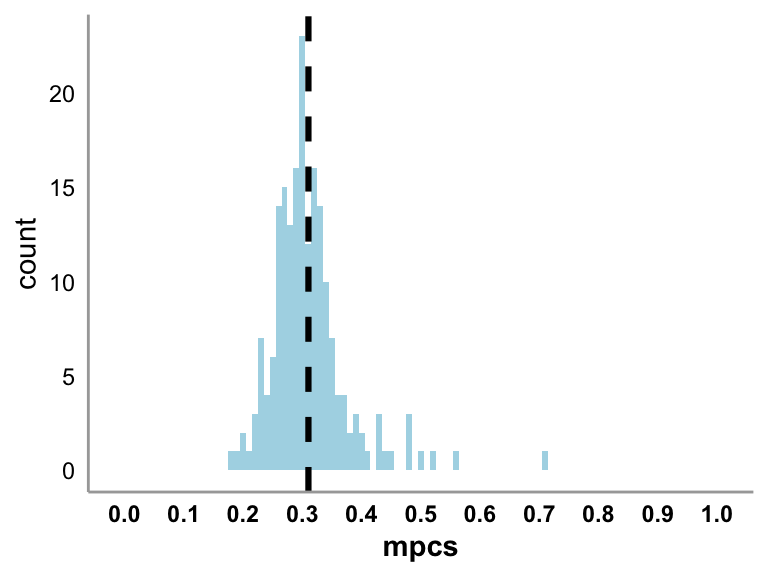

```r
df_lebe_elg %>%
  filter(!is.na(mpcs)) %>%
  ggplot(aes(x = mpcs)) +
  geom_histogram(fill = "lightblue",
                 binwidth = 0.01) +
  scale_x_continuous(breaks = seq(0,1,0.1),
                     limits = c(-0.01,1.01)) +
  ylab("count") +
  geom_vline(xintercept = mean(df_lebe_elg$mpcs,na.rm = T),
             color = "black",
             linetype = "dashed",
             size = 1.1) +
  theme(panel.grid.major = element_blank(),
        panel.grid.minor = element_blank(),
        panel.background = element_blank(),
        axis.ticks = element_blank(),
        axis.line = element_line(color = "grey66"),
        axis.text.y = element_text(color = "black"),
        axis.text.x = element_text(color = "black",
                                   face = "bold"),
        axis.title.x = element_text(color = "black",
                                   face = "bold"))
```

#### MRL

Mean Resultant Length. This is the average of unit-normalized vectors. So, basically, it tells us how tightly each reason the person gives points in the same direction. I took ones where it was only one reason. Also, for both of these measures, we might consider controlling for the number of reasons.

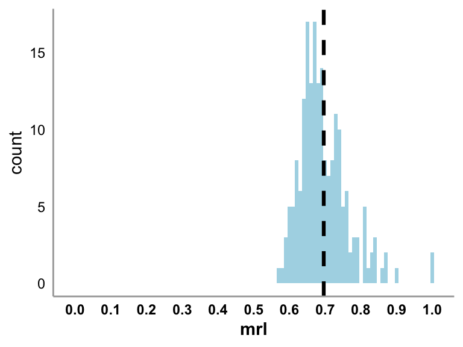

```r
df_lebe_elg %>%
  filter(!is.na(mrl)) %>%
  ggplot(aes(x = mrl)) +
  geom_histogram(fill = "lightblue",
                 binwidth = 0.01) +
  scale_x_continuous(breaks = seq(0,1,0.1),
                     limits = c(-0.01,1.01)) +
  ylab("count") +
  geom_vline(xintercept = mean(df_lebe_elg$mrl,na.rm = T),
             color = "black",
             linetype = "dashed",
             size = 1.1) +
  theme(panel.grid.major = element_blank(),
        panel.grid.minor = element_blank(),
        panel.background = element_blank(),
        axis.ticks = element_blank(),
        axis.line = element_line(color = "grey66"),
        axis.text.y = element_text(color = "black"),
        axis.text.x = element_text(color = "black",
                                   face = "bold"),
        axis.title.x = element_text(color = "black",
                                   face = "bold"))
```

### Cluster analysis

I took the embeddings of the gpt-generated reasons and clustered them using k-means clustering. These are the top-five reasons in each cluster. The label was generated by chat-gpt.

```r
top_examples %>%
  select(-cluster) %>%
  kbl() %>%
  kable_styling(bootstrap_options = "hover",
                position = "left") %>%
  scroll_box(width = "100%", height = "400px")
```

| cluster_label | reason | cosine_to_centroid |
| --- | --- | --- |
| Personal Agency | personal expectations | 0.6549430 |
| Personal Agency | personal growth | 0.6536730 |
| Personal Agency | personal struggles | 0.6405547 |
| Personal Agency | self-reflection | 0.6287556 |
| Personal Agency | personal choices | 0.6150092 |
| Family Dynamics | family issues | 0.7300505 |
| Family Dynamics | family dynamics | 0.7124517 |
| Family Dynamics | family expectations | 0.6882800 |
| Family Dynamics | relationship changes | 0.6461756 |
| Family Dynamics | single parenthood | 0.6444465 |
| Digital Access | technology access | 0.7263275 |
| Digital Access | technology changes | 0.6813101 |
| Digital Access | technology advancement | 0.6804550 |
| Digital Access | education access | 0.6461874 |
| Digital Access | job access | 0.6452334 |
| Opportunity Barriers | work limitations | 0.6690951 |
| Opportunity Barriers | social exclusion | 0.6570485 |
| Opportunity Barriers | exclusion | 0.6566692 |
| Opportunity Barriers | limited access | 0.6466282 |
| Opportunity Barriers | limited opportunities | 0.6463544 |
| Societal Change | societal trends | 0.7650135 |
| Societal Change | social trends | 0.7574744 |
| Societal Change | societal values | 0.7573283 |
| Societal Change | social changes | 0.7382289 |
| Societal Change | societal change | 0.7349736 |
| Inequality | income disparity | 0.8380072 |
| Inequality | economic disparity | 0.8247317 |
| Inequality | education gap | 0.8137225 |
| Inequality | education gaps | 0.8052966 |
| Inequality | education disparity | 0.7868005 |
| Financial Insecurity | financial struggles | 0.8018595 |
| Financial Insecurity | financial insecurity | 0.7879412 |
| Financial Insecurity | financial situations | 0.7811631 |
| Financial Insecurity | financial strain | 0.7497424 |
| Financial Insecurity | financial status | 0.7475970 |
| Support Deficit | lack of recognition | 0.7313787 |
| Support Deficit | lack of opportunities | 0.7241402 |
| Support Deficit | lack of support | 0.7218493 |
| Support Deficit | lack of progress | 0.7187135 |
| Support Deficit | lack of guidance | 0.7079137 |
| Career Instability | job stagnation | 0.7761035 |
| Career Instability | career stagnation | 0.7640864 |
| Career Instability | career loss | 0.7430161 |
| Career Instability | career uncertainty | 0.7314593 |
| Career Instability | employment instability | 0.7283597 |

Then, I wanted to assign a cluster to each participant. So, for each participant, I took the mean of their embeddings, and then took the cosine similarity of that mean with each cluster’s centroid. The highest value is the cluster that the participant was assigned to. Below, I’ll show participants’ assigned cluster, cosine similarity to cluster centroid, and open response. Let’s see if this passes the smell test.

| cluster_label | avg_cosine_to_cluster | describe |
| --- | --- | --- |
| Personal Agency | 0.4244920 | Feeling left behind might mean everyone else has a life and has accomplished something and you might now feel that way. I don’t feel left behind. My life feels full, I feel accomplished, I’m happy wit… |
| Financial Insecurity | 0.5395258 | I feel left behind economically and job wise. No matter what I do nothing is really working out for me. I also feel left behind in life. I have no family and do not have a house of my own. |
| Financial Insecurity | 0.4916186 | I have next to no income, I am disabled, and I don’t qualify for government benefits since I don’t have enough money for more up to date doctors notes. It’s really disheartening and I see the people I… |
| Inequality | 0.6487413 | Not being given equal opportunity in life in regards to school, jobs, and extracurricular activities. I would not say i was necessarily left behind but my parents did have to do some work to get me in… |
| Career Instability | 0.5320269 | I feel left behind in terms of finances and a career. I’ve been unemployed for 9 months now and it sucks that I am unable to find a job. I’ve been making income through gig work, but it feels like I’m… |
| Personal Agency | 0.4244920 | I don’t really feel left behind, as things have turned out well in my life. I make decent money, actually enjoy my job and have an amazing life partner |
| Financial Insecurity | 0.5421052 | For me, being left behind relates to times when I have struggled in my life. Financially, when I have struggled, I am someone who falls between the cracks/was just beyond qualification for help. I als… |
| Personal Agency | 0.4975779 | I feel left behind due to my lack of experiences. I have little to no social skills and my finances aren’t the greatest but improving due to effort. I feel left behind due my own actions not the fault… |
| Financial Insecurity | 0.6250084 | I think it mainly means financially left behind. It seems like it was easier to afford a home in the past, for example. My parents were able to buy a nice house with a huge garage and backyard on two … |
| Financial Insecurity | 0.5422613 | I am behind because I will never be able to afford anything. I will never be able to afford a house, and I can just hope that my parents keep theirs so that I can inherit it. I am also not going to ha… |
| Digital Access | 0.5556553 | I guess I could feel left behind because of technology or being part of the culture. I don’t feel left behind because I am tech savvy and don’t need to feel connected to the world in a way that i need… |
| Career Instability | 0.4912405 | I feel left behind due to not progressing in most areas compared to others in my age and life stage. I’m behind on my career, family, and just everything it seems |
| Financial Insecurity | 0.5893489 | I think it means how you evaluate your life and your contentment with it relative to expectations. I feel I’m currently struggling with a number of issues both financially and with my relationships as… |
| Digital Access | 0.4662106 | I feel that I am left behind. I was trained in Law Enforcement and did that for 7 years. Due to my partners murder, I developed crippling anxiety and left the profession. I then became a bookkeeper. h… |
| Financial Insecurity | 0.5056108 | I feel left behind as a single parent because I struggle a lot to keep myself afloat. I have a lot to juggle in my daily life with very little support. |
| Inequality | 0.5898288 | I feel left behind by employment and other issues like women getting more attention than men these days. Especially when it comes to being employed. There are better chances for women to be employed t… |
| Career Instability | 0.4543068 | Sometimes I feel left behind when I see people my age already doing things I want to do, like having better careers and nicer homes, while I’m still working towards those goals. It makes me feel like … |
| Career Instability | 0.5218453 | Right now I feel a little left behind because of the job market. It is very hard getting a job that pays well right now. No jobs in this small town. |
| Opportunity Barriers | 0.4754406 | The only way I feel left behind is because I am underestimated due to my age. I am active, strong, healthy, computer literate, smartphone literate, and stay on top of the news. I am routinely outright… |
| Financial Insecurity | 0.5648508 | I don’t feel left behind in any sense of the phrase but given the high cost of living I can understand why many feel like they can barely survive day to day with no hope of improving their situation a… |
| Personal Agency | 0.4790865 | I feel left behind as I don’t think I value the same things that my peers value. I value the Earth and nature, and I spend a lot of my time immersed in the outdoors. I feel like most people are more f… |
| Opportunity Barriers | 0.5564978 | It means not represented by the status quo and not having your voice represented by your elected officials. |
| Inequality | 0.5104988 | I think of left behind as whether I have more opportunities and financial security as my parents. It is a generational measure. |
| Financial Insecurity | 0.5479625 | I think financially. Trying to make money today seems to be pretty hard to do. I enjoy making content online, but it is hard to stand out! |
| Opportunity Barriers | 0.4936551 | Age is discriminated agains in this country. It is especially difficult to find employment regardless of education and years of experience. With age comes knowledge and wisdom which is not thought of … |
| Support Deficit | 0.5122143 | I felt left behind because I am being taxed so much that I can not accomplish my life’s goals. My elected representatives seem unaware and unconcerned about the level of taxation that is holding peopl… |
| Financial Insecurity | 0.4882763 | I feel left behind because, through no (or little) fault of my own, I have been out of the workforce for almost 9 years. Took care of a family member after a stroke, covid, mental health challenges af… |
| Support Deficit | 0.5535927 | like others have made it in life and you havent gotten anywhere,you just stagnant ,thigs are not going on well with you, |
| Family Dynamics | 0.5276077 | While growing up as one of four kids I often felt left behind, ignored or lost. Pretty sure my parents liked the other siblings better than me and I think at age 66 that holds true . I feel bad but th… |
| Financial Insecurity | 0.5188853 | I feel left behind because I pay a good amount of taxes as a single person living in an expensive place like California, and I don’t get anything in return for it. |

[output cut: 168 more lines]

This looks pretty good, actually.  
Let’s get a distribution of categories.

```r
df_lebe_elg %>%
  group_by(cluster_label) %>%
  summarise(N = n()) %>%
  ungroup() %>%
  mutate(Perc = round(100*(N/sum(N)),2)) %>%
  ungroup() %>%
  arrange(desc(N)) %>%
  kbl() %>%
  kable_styling(bootstrap_options = "hover",
                full_width = F,
                position = "left")
```

| cluster_label | N | Perc |
| --- | --- | --- |
| Financial Insecurity | 39 | 19.70 |
| Personal Agency | 35 | 17.68 |
| Opportunity Barriers | 27 | 13.64 |
| Career Instability | 23 | 11.62 |
| Support Deficit | 21 | 10.61 |
| Inequality | 16 | 8.08 |
| Digital Access | 14 | 7.07 |
| Family Dynamics | 12 | 6.06 |
| Societal Change | 11 | 5.56 |

Cool.

## Outcome measures

### Support for anti-democratic practices

1 = *Strongly Disagree* to 7 = *Strongly Agree*  
1. The [INPARTY] should reduce the number of polling stations in areas that support the [OUTPARTY].  
2. The [INPARTY] should not accept the results of elections if they lose.  
3. The [INPARTY] should ignore unfavorable court rulings.  
4. When a [INPARTY] candidate questions the outcome of an election, other [INPARTY] members should be more loyal to the [INPARTY] than to election rules or the constitution.  
5. The government should be able to censor media sources that spend more time attacking the [INPARTY] than the [OUTPARTY].

Cronbach’s alpha = 0.83

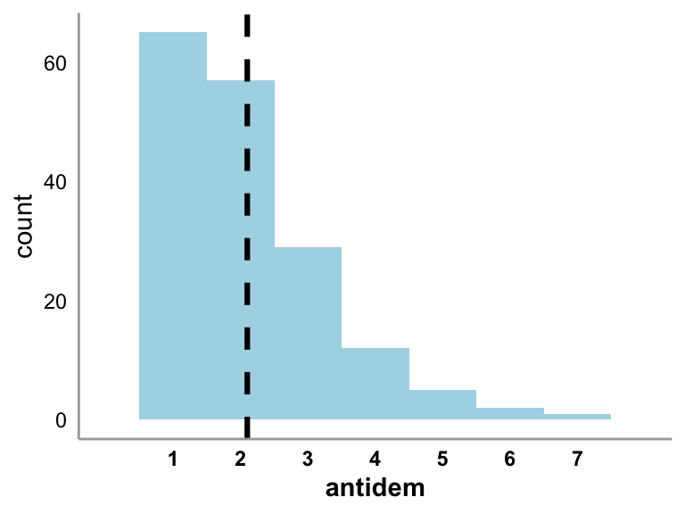

```r
df_lebe_elg %>%
  ggplot(aes(x = antidem)) +
  geom_histogram(fill = "lightblue",
                 binwidth = 1) +
  scale_x_continuous(breaks = seq(1,7,1),
                     limits = c(0,8)) +
  ylab("count") +
  geom_vline(xintercept = mean(df_lebe_elg$antidem,na.rm = T),
             color = "black",
             linetype = "dashed",
             size = 1.1) +
  theme(panel.grid.major = element_blank(),
        panel.grid.minor = element_blank(),
        panel.background = element_blank(),
        axis.ticks = element_blank(),
        axis.line = element_line(color = "grey66"),
        axis.text.y = element_text(color = "black"),
        axis.text.x = element_text(color = "black",
                                   face = "bold"),
        axis.title.x = element_text(color = "black",
                                   face = "bold"))
```

### Ideal candidate

We would like to ask you about your ideal political candidate.

#### Experience

Thinking about experience with politics, where would your ideal candidate fall?  
1 = *Outsider* (no prior political office); 7 = *Insider* (many years in political office)

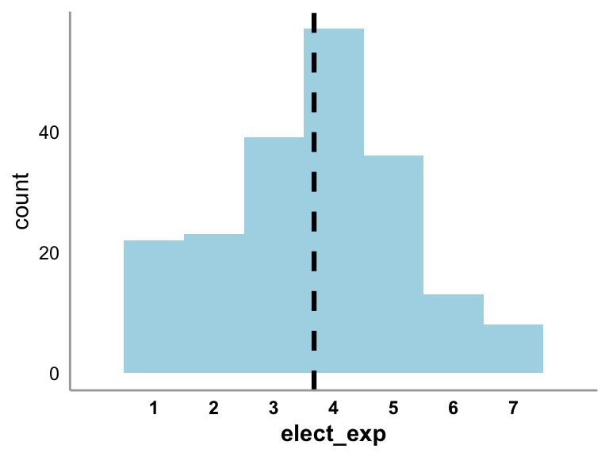

```r
df_lebe_elg %>%
  ggplot(aes(x = elect_exp)) +
  geom_histogram(fill = "lightblue",
                 binwidth = 1) +
  scale_x_continuous(breaks = seq(1,7,1),
                     limits = c(0,8)) +
  ylab("count") +
  geom_vline(xintercept = mean(df_lebe_elg$elect_exp,na.rm = T),
             color = "black",
             linetype = "dashed",
             size = 1.1) +
  theme(panel.grid.major = element_blank(),
        panel.grid.minor = element_blank(),
        panel.background = element_blank(),
        axis.ticks = element_blank(),
        axis.line = element_line(color = "grey66"),
        axis.text.y = element_text(color = "black"),
        axis.text.x = element_text(color = "black",
                                   face = "bold"),
        axis.title.x = element_text(color = "black",
                                   face = "bold"))
```

#### Change

Thinking about how they would approach change, what approach would you like them to take?  
1 = *Sweeping* (bold, radical changes); 7 = *Incremental* (smaller, step-by-step changes)

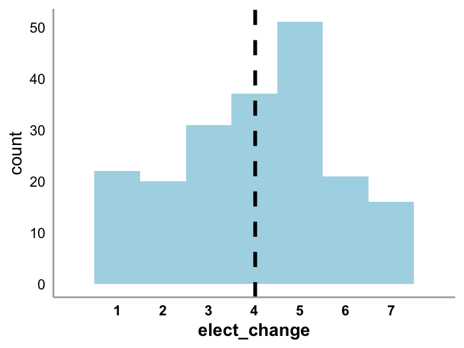

```r
df_lebe_elg %>%
  ggplot(aes(x = elect_change)) +
  geom_histogram(fill = "lightblue",
                 binwidth = 1) +
  scale_x_continuous(breaks = seq(1,7,1),
                     limits = c(0,8)) +
  ylab("count") +
  geom_vline(xintercept = mean(df_lebe_elg$elect_change,na.rm = T),
             color = "black",
             linetype = "dashed",
             size = 1.1) +
  theme(panel.grid.major = element_blank(),
        panel.grid.minor = element_blank(),
        panel.background = element_blank(),
        axis.ticks = element_blank(),
        axis.line = element_line(color = "grey66"),
        axis.text.y = element_text(color = "black"),
        axis.text.x = element_text(color = "black",
                                   face = "bold"),
        axis.title.x = element_text(color = "black",
                                   face = "bold"))
```

#### Economic policy

Thinking about their economic platform, which positions would your ideal candidate advance?  
1 = *Free Market* (low corporate taxes, deregulation); 7 = *Redistributive* (wealth tax, stronger unions)

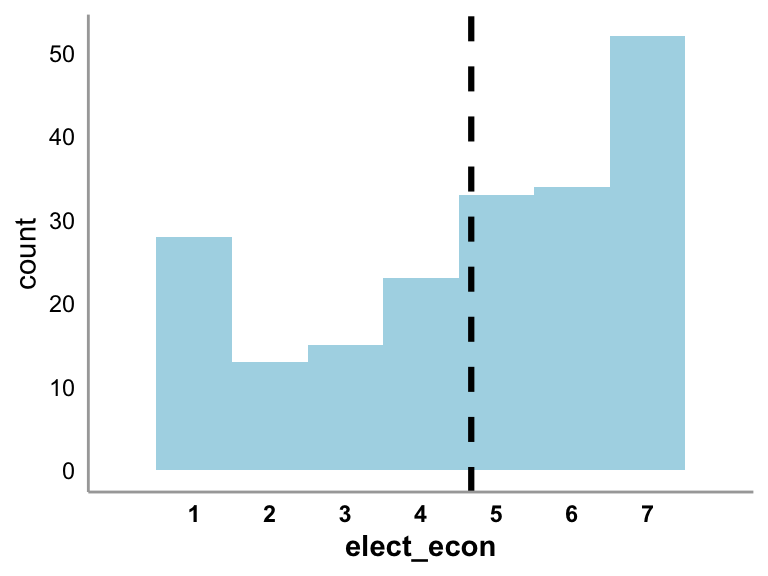

```r
df_lebe_elg %>%
  ggplot(aes(x = elect_econ)) +
  geom_histogram(fill = "lightblue",
                 binwidth = 1) +
  scale_x_continuous(breaks = seq(1,7,1),
                     limits = c(0,8)) +
  ylab("count") +
  geom_vline(xintercept = mean(df_lebe_elg$elect_econ,na.rm = T),
             color = "black",
             linetype = "dashed",
             size = 1.1) +
  theme(panel.grid.major = element_blank(),
        panel.grid.minor = element_blank(),
        panel.background = element_blank(),
        axis.ticks = element_blank(),
        axis.line = element_line(color = "grey66"),
        axis.text.y = element_text(color = "black"),
        axis.text.x = element_text(color = "black",
                                   face = "bold"),
        axis.title.x = element_text(color = "black",
                                   face = "bold"))
```

#### Cultural issues

Thinking about cultural issues, which positions would your ideal candidate advance?  
1 = *Conservative* (pro-life, stronger police, immigration crackdown); 7 = *Progressive* (pro-choice, minority rights, inclusive immigration)

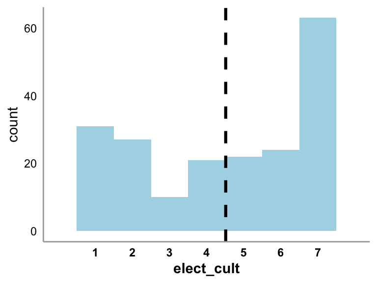

```r
df_lebe_elg %>%
  ggplot(aes(x = elect_cult)) +
  geom_histogram(fill = "lightblue",
                 binwidth = 1) +
  scale_x_continuous(breaks = seq(1,7,1),
                     limits = c(0,8)) +
  ylab("count") +
  geom_vline(xintercept = mean(df_lebe_elg$elect_cult,na.rm = T),
             color = "black",
             linetype = "dashed",
             size = 1.1) +
  theme(panel.grid.major = element_blank(),
        panel.grid.minor = element_blank(),
        panel.background = element_blank(),
        axis.ticks = element_blank(),
        axis.line = element_line(color = "grey66"),
        axis.text.y = element_text(color = "black"),
        axis.text.x = element_text(color = "black",
                                   face = "bold"),
        axis.title.x = element_text(color = "black",
                                   face = "bold"))
```

### Anti-establishment sentiment

1 = *Strongly Disagree* to 7 = *Strongly Agree*  
1. The US’s economy is rigged to advantage the rich and powerful.  
2. Traditional politicians and parties don’t care about people like me.  
3. Experts in this country don’t understand the lives of people like me.  
4. Most of the time we can trust people in the government to do what is right [R].

Cronbach’s alpha = 0.72

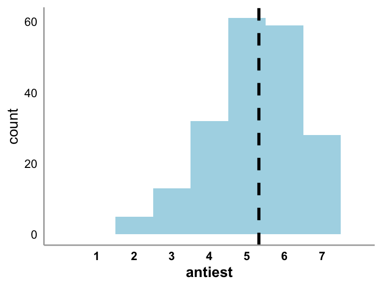

```r
df_lebe_elg %>%
  ggplot(aes(x = antiest)) +
  geom_histogram(fill = "lightblue",
                 binwidth = 1) +
  scale_x_continuous(breaks = seq(1,7,1),
                     limits = c(0,8)) +
  ylab("count") +
  geom_vline(xintercept = mean(df_lebe_elg$antiest,na.rm = T),
             color = "black",
             linetype = "dashed",
             size = 1.1) +
  theme(panel.grid.major = element_blank(),
        panel.grid.minor = element_blank(),
        panel.background = element_blank(),
        axis.ticks = element_blank(),
        axis.line = element_line(color = "grey66"),
        axis.text.y = element_text(color = "black"),
        axis.text.x = element_text(color = "black",
                                   face = "bold"),
        axis.title.x = element_text(color = "black",
                                   face = "bold"))
```

### Trust in institutions

We would now like to ask you a question about how much trust you have in certain institutions and groups. For each of the following institutions, please indicate if you trust it a lot, trust it somewhat, do not trust it very much, or do not trust it at all?  
1. Congress  
2. The Government  
3. The judiciary  
4. Scientists  
5. The political parties  
6. Traditional newsmedia

Cronbach’s alpha = 0.83

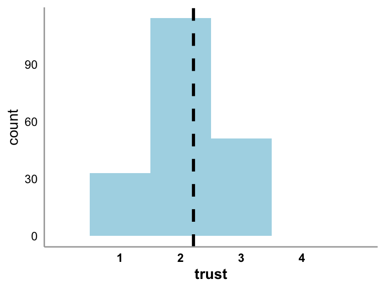

```r
df_lebe_elg %>%
  ggplot(aes(x = trust)) +
  geom_histogram(fill = "lightblue",
                 binwidth = 1) +
  scale_x_continuous(breaks = seq(1,4,1),
                     limits = c(0,5)) +
  ylab("count") +
  geom_vline(xintercept = mean(df_lebe_elg$trust,na.rm = T),
             color = "black",
             linetype = "dashed",
             size = 1.1) +
  theme(panel.grid.major = element_blank(),
        panel.grid.minor = element_blank(),
        panel.background = element_blank(),
        axis.ticks = element_blank(),
        axis.line = element_line(color = "grey66"),
        axis.text.y = element_text(color = "black"),
        axis.text.x = element_text(color = "black",
                                   face = "bold"),
        axis.title.x = element_text(color = "black",
                                   face = "bold"))
```

Broken up:

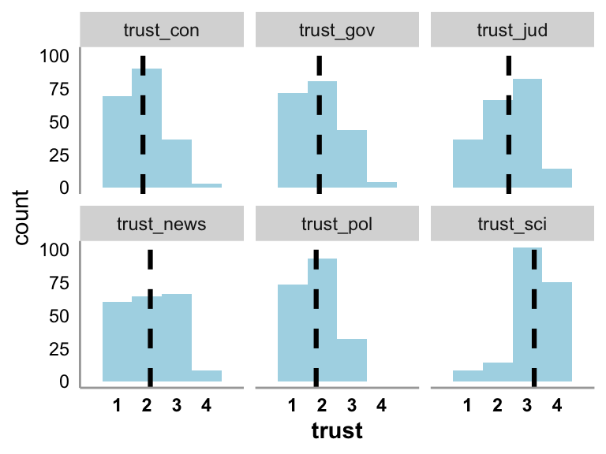

```r
means <- df_lebe_elg %>%
  dplyr::select(PID,trust_con:trust_news) %>%
  pivot_longer(-PID,
               names_to = "inst",
               values_to = "trust") %>%
  filter(!is.na(trust)) %>%
  group_by(inst) %>%
  summarise(score = mean(trust)) %>%
  ungroup()

df_lebe_elg %>%
  dplyr::select(PID,trust_con:trust_news) %>%
  pivot_longer(-PID,
               names_to = "inst",
               values_to = "trust") %>%
  filter(!is.na(trust)) %>%
  ggplot(aes(x = trust)) +
  geom_histogram(fill = "lightblue",
                 binwidth = 1) +
  scale_x_continuous(breaks = seq(1,4,1),
                     limits = c(0,5)) +
  ylab("count") +
  geom_vline(data = means,mapping = aes(xintercept = score),
             color = "black",
             linetype = "dashed",
             size = 1.1) +
  theme(panel.grid.major = element_blank(),
        panel.grid.minor = element_blank(),
        panel.background = element_blank(),
        axis.ticks = element_blank(),
        axis.line = element_line(color = "grey66"),
        axis.text.y = element_text(color = "black"),
        axis.text.x = element_text(color = "black",
                                   face = "bold"),
        axis.title.x = element_text(color = "black",
                                   face = "bold")) +
  facet_wrap(~inst,nrow = 2)
```

# Analysis

## Correlations

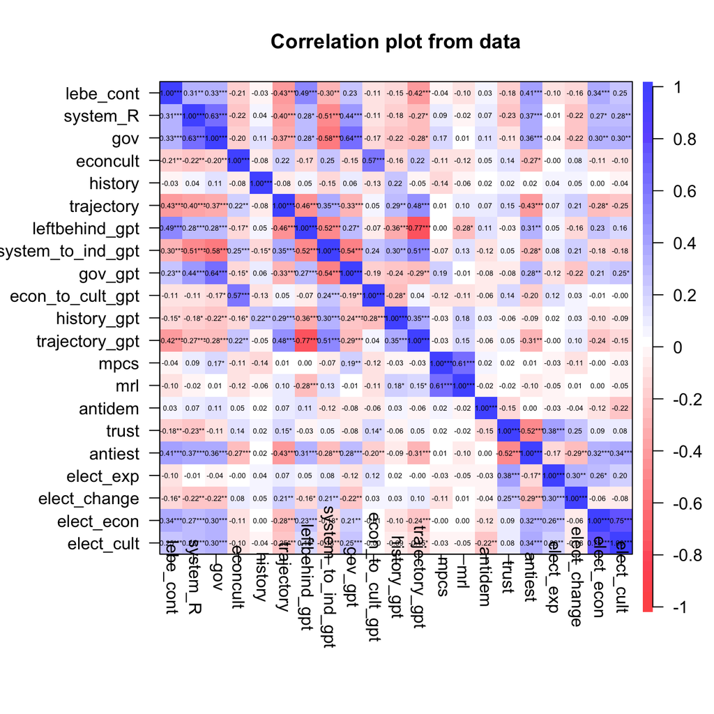

To explore these correlations and more, see here:  
Shiny App: Correlations

## Interactions

There are a bunch of ways to interact these variables. Feel free to explore here:  
Shiny App: Interactions  
Note that these are just raw interactions, without controlling for main effects or any other variables. Let’s start adding controls in the following linear models.

## Linear models

Ok, now to run some actual stats. We want to see if these correlations and interactions hold when controlling for some important variables. I’ll show a few of them below, but if you want to try some yourself, feel free to explore here:  
Shiny App: Linear Models

### DV: Candidate support for sweeping-incremental change

Just as a reminder, this is the measure for this DV…  
Thinking about how they would approach change, what approach would you like them to take?  
1 = *Sweeping* (bold, radical changes); 7 = *Incremental* (smaller, step-by-step changes)

#### Model 1

**Outcome:** Incremental change candidate  
**Predictor:** left behind - continuous  
**Controls:** political ideology (conservatism), party ID, age, income, education, race, gender

```r
m1 <- lm(elect_change ~ lebe_cont + ideo_con + party_gen + age + income_num + edu_num + race + gender,data = df_lebe_elg)

apa_lm <- apa_print(m1)

kbl(apa_lm$table) %>%
  kable_styling(bootstrap_options = "hover",
                full_width = F,
                position = "left")
```

| term | estimate | conf.int | statistic | df | p.value |
| --- | --- | --- | --- | --- | --- |
| Intercept | 4.91 | [3.09, 6.73] | 5.32 | 168 | < .001 |
| Lebe cont | -0.01 | [-0.02, 0.00] | -2.75 | 168 | .007 |
| Ideo con | -0.14 | [-0.33, 0.05] | -1.45 | 168 | .149 |
| Party genIndependent | 0.45 | [-0.27, 1.17] | 1.24 | 168 | .217 |
| Party genNo preference | -0.18 | [-2.68, 2.32] | -0.14 | 168 | .889 |
| Party genOther party | 0.84 | [-1.89, 3.56] | 0.61 | 168 | .545 |
| Party genRepublican | 0.60 | [-0.43, 1.63] | 1.15 | 168 | .252 |
| Age | -0.01 | [-0.04, 0.01] | -1.38 | 168 | .170 |
| Income num | 0.06 | [-0.05, 0.18] | 1.10 | 168 | .272 |
| Edu num | -0.09 | [-0.31, 0.13] | -0.77 | 168 | .444 |
| RaceBlack or African American | 0.54 | [-0.78, 1.87] | 0.81 | 168 | .420 |
| RaceHispanic, Latino, or Spanish origin | -0.31 | [-1.73, 1.11] | -0.43 | 168 | .665 |
| RaceMiddle Eastern or North African | -0.99 | [-4.62, 2.63] | -0.54 | 168 | .589 |
| Racemultiracial | 0.24 | [-1.27, 1.76] | 0.32 | 168 | .751 |
| RaceWhite | 0.56 | [-0.49, 1.61] | 1.05 | 168 | .297 |
| Genderwoman | -0.01 | [-0.53, 0.51] | -0.04 | 168 | .971 |

#### Model 2

**Outcome:** Incremental change candidate  
**Predictor:** systemic reason for being left behind  
**Controls:** political ideology (conservatism), party ID, age, income, education, race, gender

```r
m1 <- lm(elect_change ~ system_R + ideo_con + party_gen + age + income_num + edu_num + race + gender,data = df_lebe_elg)

apa_lm <- apa_print(m1)

kbl(apa_lm$table) %>%
  kable_styling(bootstrap_options = "hover",
                full_width = F,
                position = "left")
```

| term | estimate | conf.int | statistic | df | p.value |
| --- | --- | --- | --- | --- | --- |
| Intercept | 4.72 | [2.97, 6.47] | 5.32 | 168 | < .001 |
| System R | -0.19 | [-0.31, -0.06] | -2.87 | 168 | .005 |
| Ideo con | -0.10 | [-0.28, 0.08] | -1.06 | 168 | .289 |
| Party genIndependent | 0.26 | [-0.47, 0.98] | 0.71 | 168 | .481 |
| Party genNo preference | -0.59 | [-3.07, 1.90] | -0.47 | 168 | .642 |
| Party genOther party | 0.21 | [-2.50, 2.93] | 0.15 | 168 | .878 |
| Party genRepublican | 0.30 | [-0.73, 1.33] | 0.57 | 168 | .568 |
| Age | -0.01 | [-0.03, 0.01] | -1.09 | 168 | .278 |
| Income num | 0.08 | [-0.04, 0.19] | 1.33 | 168 | .186 |
| Edu num | -0.03 | [-0.25, 0.19] | -0.24 | 168 | .808 |
| RaceBlack or African American | 0.89 | [-0.44, 2.21] | 1.32 | 168 | .189 |
| RaceHispanic, Latino, or Spanish origin | 0.02 | [-1.42, 1.46] | 0.02 | 168 | .981 |
| RaceMiddle Eastern or North African | -1.04 | [-4.66, 2.57] | -0.57 | 168 | .569 |
| Racemultiracial | 0.64 | [-0.88, 2.17] | 0.83 | 168 | .407 |
| RaceWhite | 0.67 | [-0.38, 1.72] | 1.26 | 168 | .210 |
| Genderwoman | -0.10 | [-0.63, 0.43] | -0.37 | 168 | .711 |

#### Model 3

**Outcome:** Incremental change candidate  
**Predictor:** systemic reason for being left behind  
**Moderator:** continuous measure of feeling left behind  
**Controls:** political ideology (conservatism), party ID, age, income, education, race, gender

```r
m1 <- lm(elect_change ~ system_R*lebe_cont + ideo_con + party_gen + age + income_num + edu_num + race + gender,data = df_lebe_elg)

apa_lm <- apa_print(m1)

kbl(apa_lm$table) %>%
  kable_styling(bootstrap_options = "hover",
                full_width = F,
                position = "left")
```

| term | estimate | conf.int | statistic | df | p.value |
| --- | --- | --- | --- | --- | --- |
| Intercept | 5.47 | [3.51, 7.44] | 5.49 | 166 | < .001 |
| System R | -0.17 | [-0.36, 0.03] | -1.71 | 166 | .089 |
| Lebe cont | -0.01 | [-0.03, 0.01] | -1.14 | 166 | .254 |
| Ideo con | -0.14 | [-0.33, 0.05] | -1.47 | 166 | .142 |
| Party genIndependent | 0.33 | [-0.39, 1.05] | 0.90 | 166 | .371 |
| Party genNo preference | -0.33 | [-2.81, 2.16] | -0.26 | 166 | .795 |
| Party genOther party | 0.49 | [-2.24, 3.22] | 0.35 | 166 | .724 |
| Party genRepublican | 0.41 | [-0.62, 1.45] | 0.79 | 166 | .430 |
| Age | -0.01 | [-0.03, 0.01] | -1.35 | 166 | .178 |
| Income num | 0.05 | [-0.06, 0.17] | 0.92 | 166 | .360 |
| Edu num | -0.06 | [-0.28, 0.16] | -0.53 | 166 | .598 |
| RaceBlack or African American | 0.74 | [-0.59, 2.06] | 1.09 | 166 | .275 |
| RaceHispanic, Latino, or Spanish origin | -0.05 | [-1.48, 1.39] | -0.06 | 166 | .950 |
| RaceMiddle Eastern or North African | -0.77 | [-4.38, 2.83] | -0.42 | 166 | .672 |
| Racemultiracial | 0.52 | [-1.01, 2.05] | 0.67 | 166 | .504 |
| RaceWhite | 0.65 | [-0.39, 1.70] | 1.23 | 166 | .220 |
| Genderwoman | -0.10 | [-0.63, 0.42] | -0.39 | 166 | .695 |
| System R $\times$ Lebe cont | 0.00 | [0.00, 0.00] | 0.26 | 166 | .798 |

#### Model 4

**Outcome:** Incremental change candidate  
**Predictor:** systemic reason for being left behind - gpt (unreversed)  
**Controls:** political ideology (conservatism), party ID, age, income, education, race, gender

```r
m1 <- lm(elect_change ~ system_to_ind_gpt + ideo_con + party_gen + age + income_num + edu_num + race + gender,data = df_lebe_elg)

apa_lm <- apa_print(m1)

kbl(apa_lm$table) %>%
  kable_styling(bootstrap_options = "hover",
                full_width = F,
                position = "left")
```

| term | estimate | conf.int | statistic | df | p.value |
| --- | --- | --- | --- | --- | --- |
| Intercept | 3.20 | [1.53, 4.86] | 3.78 | 168 | < .001 |
| System to ind gpt | 0.21 | [0.07, 0.34] | 3.01 | 168 | .003 |
| Ideo con | -0.12 | [-0.30, 0.07] | -1.26 | 168 | .208 |
| Party genIndependent | 0.36 | [-0.35, 1.08] | 1.00 | 168 | .317 |
| Party genNo preference | -0.65 | [-3.13, 1.84] | -0.51 | 168 | .608 |
| Party genOther party | 0.35 | [-2.35, 3.05] | 0.26 | 168 | .799 |
| Party genRepublican | 0.50 | [-0.52, 1.52] | 0.97 | 168 | .335 |
| Age | -0.01 | [-0.03, 0.01] | -0.96 | 168 | .340 |
| Income num | 0.09 | [-0.03, 0.20] | 1.53 | 168 | .128 |
| Edu num | -0.03 | [-0.24, 0.19] | -0.23 | 168 | .821 |
| RaceBlack or African American | 0.89 | [-0.43, 2.22] | 1.33 | 168 | .184 |
| RaceHispanic, Latino, or Spanish origin | -0.07 | [-1.50, 1.36] | -0.09 | 168 | .925 |
| RaceMiddle Eastern or North African | -1.13 | [-4.72, 2.47] | -0.62 | 168 | .537 |
| Racemultiracial | 0.33 | [-1.17, 1.84] | 0.44 | 168 | .663 |
| RaceWhite | 0.62 | [-0.43, 1.67] | 1.17 | 168 | .244 |
| Genderwoman | -0.05 | [-0.57, 0.47] | -0.18 | 168 | .858 |

#### Model 5

**Outcome:** Incremental change candidate  
**Predictor:** trajectory  
**Controls:** political ideology (conservatism), party ID, age, income, education, race, gender

```r
m1 <- lm(elect_change ~ trajectory + ideo_con + party_gen + age + income_num + edu_num + race + gender,data = df_lebe_elg)

apa_lm <- apa_print(m1)

kbl(apa_lm$table) %>%
  kable_styling(bootstrap_options = "hover",
                full_width = F,
                position = "left")
```

| term | estimate | conf.int | statistic | df | p.value |
| --- | --- | --- | --- | --- | --- |
| Intercept | 2.99 | [1.30, 4.69] | 3.49 | 168 | < .001 |
| Trajectory | 0.29 | [0.11, 0.47] | 3.12 | 168 | .002 |
| Ideo con | -0.12 | [-0.31, 0.06] | -1.31 | 168 | .191 |
| Party genIndependent | 0.31 | [-0.41, 1.02] | 0.84 | 168 | .401 |
| Party genNo preference | -0.75 | [-3.23, 1.73] | -0.60 | 168 | .550 |
| Party genOther party | 0.52 | [-2.18, 3.22] | 0.38 | 168 | .703 |
| Party genRepublican | 0.41 | [-0.62, 1.43] | 0.79 | 168 | .433 |
| Age | -0.01 | [-0.03, 0.01] | -0.90 | 168 | .369 |
| Income num | 0.06 | [-0.05, 0.18] | 1.06 | 168 | .291 |
| Edu num | -0.04 | [-0.26, 0.18] | -0.33 | 168 | .738 |
| RaceBlack or African American | 0.80 | [-0.51, 2.12] | 1.21 | 168 | .230 |
| RaceHispanic, Latino, or Spanish origin | -0.21 | [-1.63, 1.20] | -0.30 | 168 | .765 |
| RaceMiddle Eastern or North African | -0.63 | [-4.26, 2.99] | -0.35 | 168 | .730 |
| Racemultiracial | 0.57 | [-0.94, 2.09] | 0.75 | 168 | .456 |
| RaceWhite | 0.84 | [-0.22, 1.90] | 1.57 | 168 | .119 |
| Genderwoman | 0.02 | [-0.49, 0.54] | 0.09 | 168 | .926 |

### DV: Candidate support for economically progressive policy

Just as a reminder, this is the measure for this DV…  
Thinking about their economic platform, which positions would your ideal candidate advance?  
1 = *Free Market* (low corporate taxes, deregulation); 7 = *Redistributive* (wealth tax, stronger unions)

#### Model 1

**Outcome:** Economically redistributive candidate  
**Predictor:** left behind - continuous  
**Controls:** political ideology (conservatism), party ID, age, income, education, race, gender

```r
m1 <- lm(elect_econ ~ lebe_cont + ideo_con + party_gen + age + income_num + edu_num + race + gender,data = df_lebe_elg)

apa_lm <- apa_print(m1)

kbl(apa_lm$table) %>%
  kable_styling(bootstrap_options = "hover",
                full_width = F,
                position = "left")
```

| term | estimate | conf.int | statistic | df | p.value |
| --- | --- | --- | --- | --- | --- |
| Intercept | 5.96 | [4.33, 7.58] | 7.23 | 168 | < .001 |
| Lebe cont | 0.02 | [0.01, 0.02] | 3.61 | 168 | < .001 |
| Ideo con | -0.48 | [-0.65, -0.31] | -5.66 | 168 | < .001 |
| Party genIndependent | -0.42 | [-1.06, 0.22] | -1.29 | 168 | .197 |
| Party genNo preference | 0.44 | [-1.80, 2.67] | 0.38 | 168 | .701 |
| Party genOther party | 0.78 | [-1.66, 3.21] | 0.63 | 168 | .530 |
| Party genRepublican | -0.60 | [-1.52, 0.32] | -1.28 | 168 | .202 |
| Age | 0.01 | [-0.01, 0.03] | 0.73 | 168 | .466 |
| Income num | 0.02 | [-0.08, 0.12] | 0.39 | 168 | .698 |
| Edu num | -0.01 | [-0.21, 0.19] | -0.12 | 168 | .906 |
| RaceBlack or African American | 0.27 | [-0.92, 1.45] | 0.44 | 168 | .657 |
| RaceHispanic, Latino, or Spanish origin | -0.37 | [-1.64, 0.90] | -0.57 | 168 | .569 |
| RaceMiddle Eastern or North African | 0.85 | [-2.39, 4.09] | 0.52 | 168 | .606 |
| Racemultiracial | -0.30 | [-1.65, 1.05] | -0.44 | 168 | .658 |
| RaceWhite | -0.63 | [-1.57, 0.31] | -1.32 | 168 | .188 |
| Genderwoman | 0.45 | [-0.01, 0.92] | 1.92 | 168 | .056 |

#### Model 2

**Outcome:** Economically redistributive candidate  
**Predictor:** systemic reason for being left behind  
**Controls:** political ideology (conservatism), party ID, age, income, education, race, gender

```r
m1 <- lm(elect_econ ~ system_R + ideo_con + party_gen + age + income_num + edu_num + race + gender,data = df_lebe_elg)

apa_lm <- apa_print(m1)

kbl(apa_lm$table) %>%
  kable_styling(bootstrap_options = "hover",
                full_width = F,
                position = "left")
```

| term | estimate | conf.int | statistic | df | p.value |
| --- | --- | --- | --- | --- | --- |
| Intercept | 6.72 | [5.10, 8.33] | 8.23 | 168 | < .001 |
| System R | 0.11 | [-0.01, 0.23] | 1.87 | 168 | .063 |
| Ideo con | -0.54 | [-0.71, -0.37] | -6.28 | 168 | < .001 |
| Party genIndependent | -0.28 | [-0.95, 0.38] | -0.84 | 168 | .404 |
| Party genNo preference | 0.86 | [-1.43, 3.15] | 0.74 | 168 | .458 |
| Party genOther party | 1.34 | [-1.15, 3.84] | 1.06 | 168 | .290 |
| Party genRepublican | -0.36 | [-1.31, 0.59] | -0.75 | 168 | .454 |
| Age | 0.00 | [-0.02, 0.02] | 0.30 | 168 | .768 |
| Income num | -0.01 | [-0.11, 0.10] | -0.14 | 168 | .891 |
| Edu num | -0.07 | [-0.27, 0.14] | -0.65 | 168 | .518 |
| RaceBlack or African American | -0.01 | [-1.23, 1.21] | -0.02 | 168 | .987 |
| RaceHispanic, Latino, or Spanish origin | -0.55 | [-1.88, 0.77] | -0.82 | 168 | .413 |
| RaceMiddle Eastern or North African | 1.18 | [-2.15, 4.50] | 0.70 | 168 | .485 |
| Racemultiracial | -0.57 | [-1.97, 0.84] | -0.80 | 168 | .426 |
| RaceWhite | -0.69 | [-1.66, 0.28] | -1.40 | 168 | .162 |
| Genderwoman | 0.48 | [-0.01, 0.96] | 1.94 | 168 | .054 |

#### Model 3

**Outcome:** Economically redistributive candidate  
**Predictor:** economic-cultural reasons  
**Controls:** political ideology (conservatism), party ID, age, income, education, race, gender

```r
m1 <- lm(elect_econ ~ econcult + ideo_con + party_gen + age + income_num + edu_num + race + gender,data = df_lebe_elg)

apa_lm <- apa_print(m1)

kbl(apa_lm$table) %>%
  kable_styling(bootstrap_options = "hover",
                full_width = F,
                position = "left")
```

| term | estimate | conf.int | statistic | df | p.value |
| --- | --- | --- | --- | --- | --- |
| Intercept | 7.44 | [5.91, 8.96] | 9.61 | 168 | < .001 |
| Econcult | -0.08 | [-0.21, 0.05] | -1.20 | 168 | .230 |
| Ideo con | -0.54 | [-0.71, -0.37] | -6.30 | 168 | < .001 |
| Party genIndependent | -0.37 | [-1.03, 0.29] | -1.10 | 168 | .274 |
| Party genNo preference | 0.87 | [-1.43, 3.18] | 0.75 | 168 | .455 |
| Party genOther party | 1.06 | [-1.45, 3.58] | 0.84 | 168 | .404 |
| Party genRepublican | -0.46 | [-1.41, 0.49] | -0.96 | 168 | .336 |
| Age | 0.00 | [-0.02, 0.02] | 0.43 | 168 | .670 |
| Income num | -0.02 | [-0.12, 0.09] | -0.35 | 168 | .727 |
| Edu num | -0.05 | [-0.25, 0.16] | -0.46 | 168 | .644 |
| RaceBlack or African American | 0.09 | [-1.13, 1.31] | 0.15 | 168 | .881 |
| RaceHispanic, Latino, or Spanish origin | -0.44 | [-1.76, 0.89] | -0.65 | 168 | .514 |
| RaceMiddle Eastern or North African | 1.35 | [-1.99, 4.68] | 0.80 | 168 | .427 |
| Racemultiracial | -0.38 | [-1.78, 1.02] | -0.54 | 168 | .593 |
| RaceWhite | -0.66 | [-1.64, 0.31] | -1.35 | 168 | .180 |
| Genderwoman | 0.44 | [-0.05, 0.93] | 1.79 | 168 | .075 |

## Extra relationships

Let’s see if the cluster categories derived from people’s open-ended responses show any patterns. So, below are the means of the left behind continuous measure, self-reported systemic explanation, self-reported government-related, self-reported economic<>cultural, support for anti-democratic practices, trust in institutions, anti-establishment sentiment, ideal candidate: experience, ideal candidate: change (sweeping to incremental), ideal candidate: economic (free market to redistributive), and ideal candidate: cultural (conservative to progressive).

```r
df_lebe_elg %>%
  group_by(cluster_label) %>%
  summarise(leftbehindcont = mean(lebe_cont,na.rm = T),
            system = mean(system_R,na.rm = T),
            gov = mean(gov,na.rm = T),
            econcult = mean(econcult,na.rm = T),
            antidem = mean(antidem,na.rm = T),
            trust = mean(trust,na.rm = T),
            antiest = mean(antiest,na.rm = T),
            elect_exp = mean(elect_exp,na.rm = T),
            elect_change = mean(elect_change,na.rm = T),
            elect_econ = mean(elect_econ,na.rm = T),
            elect_cult = mean(elect_cult,na.rm = T)) %>%
  ungroup() %>%
  kbl() %>%
  kable_styling(bootstrap_options = "hover",
                full_width = F,
                position = "left")
```

| cluster_label | leftbehindcont | system | gov | econcult | antidem | trust | antiest | elect_exp | elect_change | elect_econ | elect_cult |
| --- | --- | --- | --- | --- | --- | --- | --- | --- | --- | --- | --- |
| Career Instability | 40.56522 | 3.913044 | 2.086956 | 2.565217 | 2.219048 | 2.181159 | 5.315217 | 4.217391 | 4.434783 | 4.565217 | 4.434783 |
| Digital Access | 40.85714 | 4.714286 | 3.000000 | 3.071429 | 2.166667 | 2.238095 | 5.714286 | 3.142857 | 3.357143 | 4.571429 | 4.500000 |
| Family Dynamics | 29.75000 | 2.416667 | 1.416667 | 3.500000 | 1.825000 | 2.125000 | 5.395833 | 3.583333 | 4.250000 | 3.833333 | 4.166667 |
| Financial Insecurity | 56.69231 | 5.102564 | 3.153846 | 2.153846 | 2.012903 | 2.119658 | 5.737179 | 3.307692 | 3.461539 | 5.512821 | 5.076923 |
| Inequality | 33.93750 | 5.375000 | 2.937500 | 2.875000 | 2.133333 | 2.312500 | 5.593750 | 4.625000 | 4.625000 | 4.750000 | 4.062500 |
| Opportunity Barriers | 29.55556 | 4.370370 | 2.555556 | 4.370370 | 1.954546 | 2.376543 | 5.074074 | 3.703704 | 4.074074 | 4.592593 | 4.666667 |
| Personal Agency | 28.65714 | 3.400000 | 1.742857 | 4.285714 | 2.237500 | 2.195238 | 4.771429 | 3.742857 | 4.228571 | 4.200000 | 4.028571 |
| Societal Change | 29.09091 | 5.090909 | 3.545454 | 4.454546 | 1.600000 | 2.287879 | 4.931818 | 3.818182 | 3.818182 | 5.181818 | 5.000000 |
| Support Deficit | 46.71429 | 4.619048 | 2.666667 | 3.571429 | 2.340000 | 2.142857 | 5.452381 | 3.190476 | 4.142857 | 4.285714 | 4.476191 |

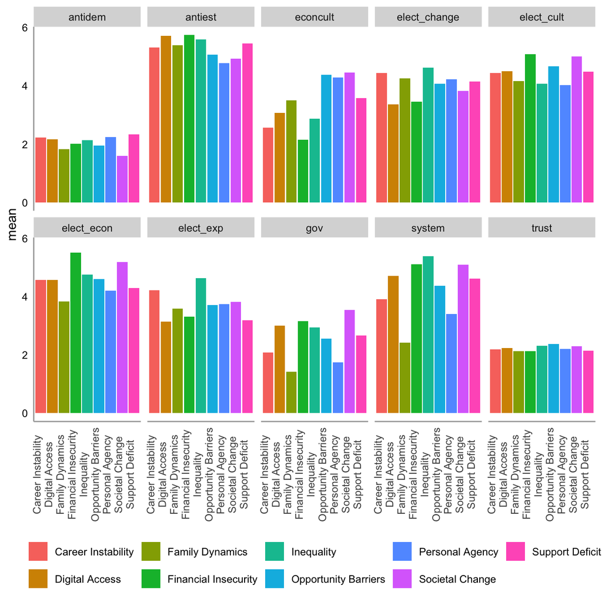